# Multi-cue recall (v3.4 - v3.6)

# Summary

Memory recall is often modeled as a process of evidence accumulation. Existing models typically assume that this accumulation process is passive, and not subject to top-down control. In contrast, recent work in perceptual and value-based decision making has suggested that similar kinds of evidence accumulation processes are guided by attention, such that evidence for attended items is accumulated faster than for non-attended items. Furthermore, attention may be adaptively allocated to different items in order to optimize a tradeoff between decision quality and the computational cost of evidence accumulation. In this project, we ask whether similar forces are at play in the context of memory recall.

# Model

We model memory recall as a process of evidence accumulation. As in the DDM or LCA, we assume that evidence is sampled at each time step and that recall occurs when the total evidence hits a threshold. To make the model solvable (by dynamic programming) we assume that the evidence for each target follows a Bernoulli distribution
$$x_t \sim \text{Bernoulli}(p),$$
where $p$ corresponds to the strength of the memory. This image shows several possible traces of evidence accumulation for a single item:

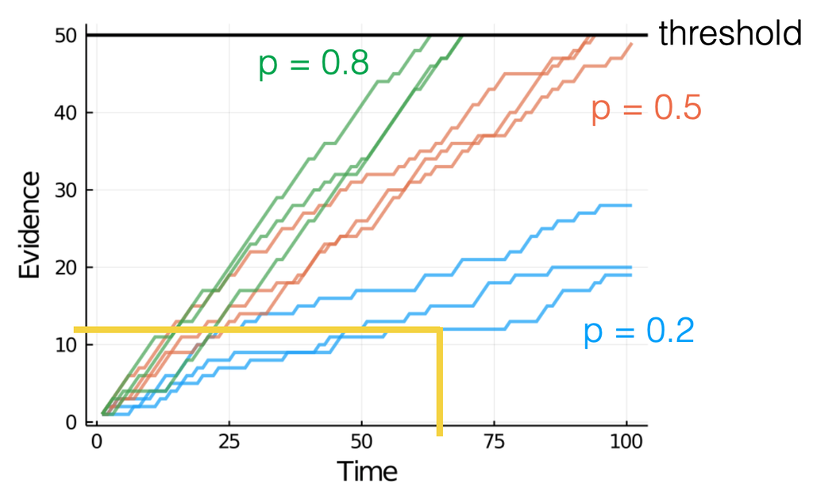

```r
knitr::include_graphics("figs/accumulation.png")
```

When multiple memories are relevant, each one has a separate accumulator. Critically, we do not assume that evidence is sampled for each item in parallel. Instead, at each time step, a policy selects one of the targets and accumulates evidence for only that target. Solving the resulting Markov decision process, we find that the optimal policy generally converges on the target with maximal memory strength (highest $p$) and only draws samples for that target until it is recalled. This is illustrated in the following plot:

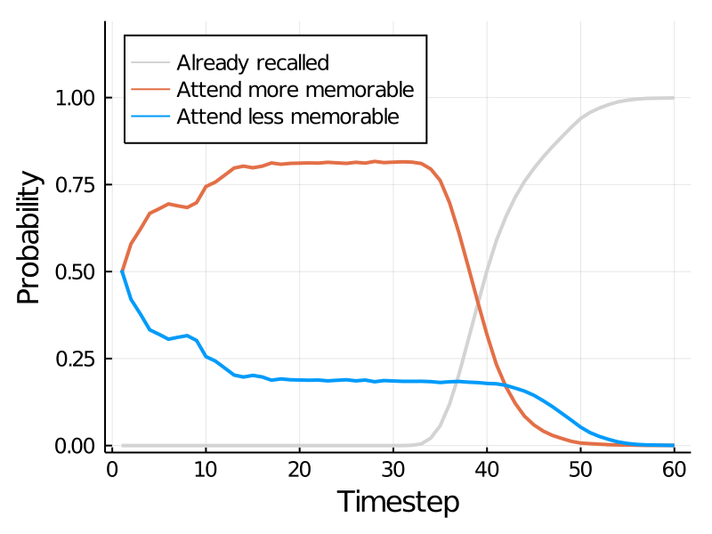

```r
knitr::include_graphics("../model/figs/simple_fixation.png")
```

# Experiment

To test the model’s predictions, we developed a modified cued-recall experiment in which participants were presented with two cues (images) on each trial and could recall the target (word) associated with either one. To create an observable behavioral correlate of targeted memory search, only one cue is visible at a time and participants use the keyboard to display each in turn. This is basically a cheap alternative to eye-tracking. The assumption is that people will look at the image they are currently trying to remember the word for. See a demo [here](http://memorygame29.herokuapp.com/?test_type=multi-recall&skip=6).

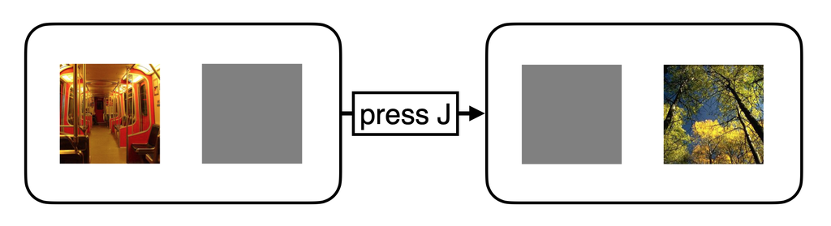

```r
knitr::include_graphics("figs/task.png")
```

The model predicts that people will spend more time looking at the cue for which the memory of the corresponding target is stronger. To test this prediction, we need a way to measure memory strength. Early attempts to manipulate memorability using established norms were not successful. Thus, we instead take the approach of measuring the strength of each cue-target pair in an earlier phase of the experiment. We’ve tried two strategies.

1. Standard cued recall task: operationalize memory strength of each pair as the average log reaction time for trials in which the participant recalled the target (with a fixed penalty for failure trials).
2. Reverse 2AFC task: operationalize memory strength as the average log reaction time to choose the correct image out of two options, when presented with the word. Note that we have reversed the role of cue and target here in order to reduce the likelihood that people develop metacognitive awareness of which images they know well in this pretest phase.

# Results

In progress.